# R Notebook

In this video we will learn the structure of the data with sample values for each attribute and we will see the five number summary statistics for numeric variables

```r
PM25 <- read.csv("PRSA_data_2010.1.1-2014.12.31.csv")
```

We will print the structure of data with sample values using str command

```r
str(PM25)
```

```
'data.frame':   43824 obs. of  13 variables:
 $ No   : int  1 2 3 4 5 6 7 8 9 10 ...
 $ year : int  2010 2010 2010 2010 2010 2010 2010 2010 2010 2010 ...
 $ month: int  1 1 1 1 1 1 1 1 1 1 ...
 $ day  : int  1 1 1 1 1 1 1 1 1 1 ...
 $ hour : int  0 1 2 3 4 5 6 7 8 9 ...
 $ pm2.5: int  NA NA NA NA NA NA NA NA NA NA ...
 $ DEWP : int  -21 -21 -21 -21 -20 -19 -19 -19 -19 -20 ...
 $ TEMP : num  -11 -12 -11 -14 -12 -10 -9 -9 -9 -8 ...
 $ PRES : num  1021 1020 1019 1019 1018 ...
 $ cbwd : chr  "NW" "NW" "NW" "NW" ...
 $ Iws  : num  1.79 4.92 6.71 9.84 12.97 ...
 $ Is   : int  0 0 0 0 0 0 0 0 0 0 ...
 $ Ir   : int  0 0 0 0 0 0 0 0 0 0 ...
```

Now, let’s show the summary statistics of the dataset

```r
summary(PM25)
```

```
       No             year          month             day             hour           pm2.5             DEWP
 Min.   :    1   Min.   :2010   Min.   : 1.000   Min.   : 1.00   Min.   : 0.00   Min.   :  0.00   Min.   :-40.000
 1st Qu.:10957   1st Qu.:2011   1st Qu.: 4.000   1st Qu.: 8.00   1st Qu.: 5.75   1st Qu.: 29.00   1st Qu.:-10.000
 Median :21913   Median :2012   Median : 7.000   Median :16.00   Median :11.50   Median : 72.00   Median :  2.000
 Mean   :21913   Mean   :2012   Mean   : 6.524   Mean   :15.73   Mean   :11.50   Mean   : 98.61   Mean   :  1.817
 3rd Qu.:32868   3rd Qu.:2013   3rd Qu.:10.000   3rd Qu.:23.00   3rd Qu.:17.25   3rd Qu.:137.00   3rd Qu.: 15.000
 Max.   :43824   Max.   :2014   Max.   :12.000   Max.   :31.00   Max.   :23.00   Max.   :994.00   Max.   : 28.000
                                                                                 NA's   :2067
      TEMP             PRES          cbwd                Iws               Is                 Ir
 Min.   :-19.00   Min.   : 991   Length:43824       Min.   :  0.45   Min.   : 0.00000   Min.   : 0.0000
 1st Qu.:  2.00   1st Qu.:1008   Class :character   1st Qu.:  1.79   1st Qu.: 0.00000   1st Qu.: 0.0000
 Median : 14.00   Median :1016   Mode  :character   Median :  5.37   Median : 0.00000   Median : 0.0000
 Mean   : 12.45   Mean   :1016                      Mean   : 23.89   Mean   : 0.05273   Mean   : 0.1949
 3rd Qu.: 23.00   3rd Qu.:1025                      3rd Qu.: 21.91   3rd Qu.: 0.00000   3rd Qu.: 0.0000
 Max.   : 42.00   Max.   :1046                      Max.   :585.60   Max.   :27.00000   Max.   :36.0000
```

Create a randomly generated train and test dataset from the Beijing PM2.5 dataset

Create a num_index variable and set it to a value equal to the number of observations int eh Beijing’s PM2.5 dataset

```r
num_index <- nrow(PM25)
```

Using the sample() function, randomly select 70% of the num_index values and store them in train_index

```r
train_index <- sample(1:num_index, 0.7*nrow(PM25))
```

Use train_index to select a random subset of rows from the Beijing PM2.5 dataset and store them in a DataFrame named PM25_Train

```r
PM25_Train <- PM25[train_index,]
```

Store the remaining obseravation into a DataFrame named PM25_test:

```r
PM25_Test <- PM25[-train_index,]
```

In this video we will visualize the pm2.5, DEWP, TEMP, and PRES variables in a time series plot and observe any patterns that may emerge over the years in these variables.

Import all the required libraries

```r
library(dplyr)
library(lubridate)
library(tidyr)
library(grid)
```

ggplot2

Now we will transform year, month and hour into datetime using lubridate package named ymd_h:

```r
PM25$datetime <- with(PM25, ymd_h(sprintf('%04d%02d%02d%02d', year, month, day,hour)))
```

Plot the PM2.5, TEMP,DEWP and PRES for all the years

```r
library(ggplot2)
```

```r
plot_pm25 <- PM25 %>%
  select(datetime, pm2.5) %>%
  na.omit() %>%
  ggplot() +
  geom_point(aes(x = datetime, y = pm2.5), size = 0.5, alpha = 0.75) +
  ylab("PM2.5")

plot_TEMP <- PM25 %>%
  select(datetime, TEMP) %>%
  na.omit() %>%
  ggplot() +
  geom_point(aes(x = datetime, y = TEMP), size = 0.5, alpha = 0.75) +
  ylab("TEMP")

plot_DEWP <- PM25 %>%
  select(datetime, DEWP) %>%
  na.omit() %>%
  ggplot() +
  geom_point(aes(x = datetime, y = DEWP), size = 0.5, alpha = 0.75) +
  ylab("DEWP")

plot_PRES <- PM25 %>%
  select(datetime, PRES) %>%
  na.omit() %>%
  ggplot() +
  geom_point(aes(x = datetime, y = PRES), size = 0.5, alpha = 0.75) +
  ylab("PRES")
```

Use the following command to plot the graph

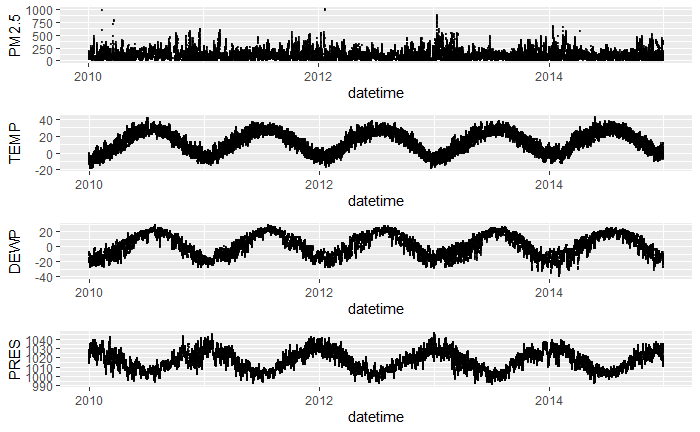

```r
grid.newpage()
grid.draw(rbind(ggplotGrob(plot_pm25), ggplotGrob(plot_TEMP),ggplotGrob(plot_DEWP),ggplotGrob(plot_PRES), size = "last"))
```

As shown in the above figure a distinct seasonality is observed year on year. While DEWP, TEMP, and PRES show seasonality (the same pattern repeating every 12 months). PM2.5 seems to have a random pattern. This is an early indicate that it is highly unlikely that we will see any effect of the three variables on PM2.5. However, let’s probe further to ascertain this hypothesis using a correlation plot and observe if there exists any relationship between the variables.

Undertake the correlation analysis

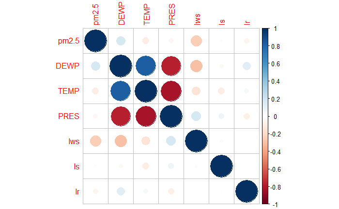

```r
library(corrplot)
# Create a new object and store the required values from PM25 into it
corr = cor(PM25[!is.na(PM25$pm2.5), c("pm2.5", "DEWP", "TEMP", "PRES", "Iws","Is","Ir")])
# Use the corrplot package to display the graphical representation of a correlation  matrix
corrplot(corr)
```

First, we compute the correlation between all the variables. The resulting correlation plot shows that there appear to be no strong correlation between PM2.5 and the other variables. However, PM2.5 and DEWP, TEMP, and lws shows some mild correlation which indicates the relationship. This should not come as surprise because threee variables follow a seasonality trend, PM2.5 seems more random. Note here that we have not done any processing or transformation to the dataset. These findings come directly from our first level of analysis.

Draw a scatter plot to explore the relationship between PM2.5 levels and other factors

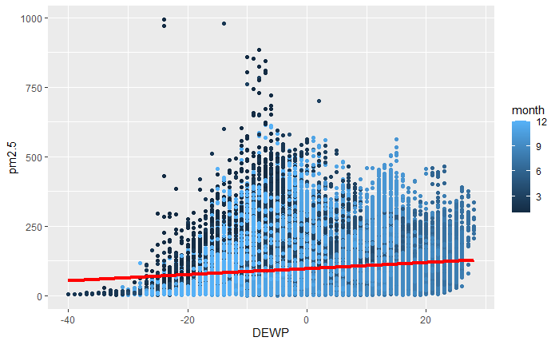

```r
# Importing library
library(ggplot2)
# Plot the scatter plot between DEWP and PM2.5 with month variable used for color
ggplot(data = PM25, aes(x = DEWP, y = pm2.5, color = month)) +geom_point() +geom_smooth(method='auto',formula=y~x, colour = "red", size =1.5)
```

The plot above shows the relationship between DEWP and PM2.5 levels

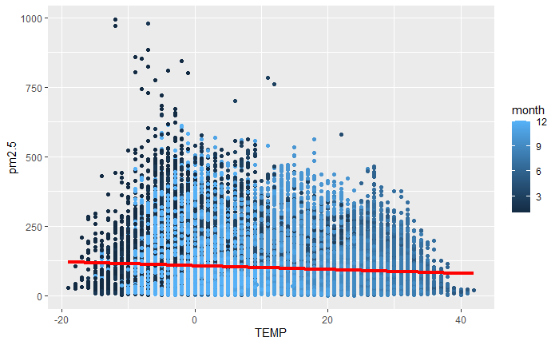

```r
ggplot(data = PM25, aes(x = TEMP, y = pm2.5, color = month)) +geom_point() +geom_smooth(method='auto',formula=y~x, colour = "red", size =1.5)
```

This plot shows the relationship between TEMP and pm2.5

Create a scatter plot between DEWP and PM2.5 with an hour of the day used for color and separate views for months of the year

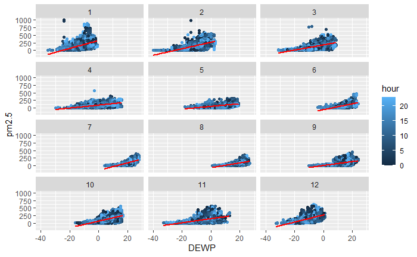

```r
ggplot(data = PM25, aes(x = DEWP, y = pm2.5, color = hour)) +geom_point() +geom_smooth(method='auto',formula=y~x, colour = "red", size =1) +facet_wrap(~ month, nrow = 4)
```

In order to gauge some relationship between variables, we used a scatter plot between PM2.5 and DEWP with a line fit. Observe that in the code, we have passed an argument to geom_smooth() that is method = “auto” which automatically decides based on the data, which model to use to fit a line.

Draw a scatter plot between PRES and PM2.5 split by months

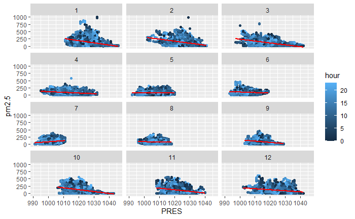

```r
ggplot(data = PM25, aes(x = PRES, y = pm2.5, color = hour)) +geom_point() +geom_smooth(method='auto',formula=y~x, colour = "red", size =1) +facet_wrap(~ month, nrow = 4)
```

Explore Simple and Multiple Regression Model

```r
simple_PM25_linear_model <- lm(pm2.5 ~ DEWP, data = PM25)
#Print summary
summary(simple_PM25_linear_model)
```

```
Call:
lm(formula = pm2.5 ~ DEWP, data = PM25)

Residuals:
    Min      1Q  Median      3Q     Max
-115.47  -61.26  -28.75   33.83  923.54

Coefficients:
            Estimate Std. Error t value Pr(>|t|)
(Intercept) 96.69984    0.44705  216.31   <2e-16 ***
DEWP         1.09325    0.03075   35.55   <2e-16 ***
---
Signif. codes:  0 ‘***’ 0.001 ‘**’ 0.01 ‘*’ 0.05 ‘.’ 0.1 ‘ ’ 1

Residual standard error: 90.69 on 41755 degrees of freedom
  (2067 observations deleted due to missingness)
Multiple R-squared:  0.02939,   Adjusted R-squared:  0.02936
F-statistic:  1264 on 1 and 41755 DF,  p-value: < 2.2e-16
```

```r
simple_PM25_multiple_model <- lm(pm2.5 ~ DEWP+TEMP+Iws, data = PM25)
#Print summary
summary(simple_PM25_multiple_model)
```

[output not shown]

In this video, We will create a new variable that stores the rolling 3-hr average of the PM2.5 variable in the Beijing PM2.5 dataset. The rolling average that will smoothen any noise from a reading of PM2.5 We will use the zoo package.

```r
PM25$datetime <- with(PM25, ymd_h(sprintf('%04d%02d%02d%02d', year, month, day,hour)))
# Remove the NAs and look at the top 6 values of the pm2.5 variable in the PM2.5 dataset
PM25_subset <- na.omit(PM25[,c("datetime","pm2.5")])
head(PM25_subset$pm2.5)
```

```
[1] 129 148 159 181 138 109
```

Store the PM2.5_subset into a zoo object of ordered observation with datetime as its index and print the top 6 values

```r
library(zoo)
zoo(PM25_subset$pm2.5, PM25_subset$datetime)
```

[output not shown]

[output cut: 280 more lines]

[output not shown]

```r
PM25_three_hour_average <- rollapply(zoo(PM25_subset$pm2.5,PM25_subset$datetime), 3, mean)
```

In this video we will find the MAE, RMSE, R-squared, Adjusted R-squared and MRR

```r
y_predicted <- predict(simple_PM25_multiple_model, data = PM25)
```

```r
y_actual <- PM25[!is.na(PM25$pm2.5),"pm2.5"]
```

```r
MAE <- mean(abs(y_actual-y_predicted))
```

```r
RMSE <- sqrt(mean((y_actual-y_predicted)^2))
```

```r
model_summary <- summary(simple_PM25_multiple_model)
model_summary$r.squared
```

```
[1] 0.2159579
```

We will find the adjusted R-squared

```r
model_summary$adj.r.squared
```

```
[1] 0.2159016
```

Find the MRR

```r
Query_RR_Vector <- c(1/3,1/4,1)
MRR <- sum(Query_RR_Vector)/length(Query_RR_Vector)
```